# Week 4: Sampling distributions

**Disclaimer: These labs rely heavily on those developed by Mike Whitlock for his BIOL 300 course at UBC https://www.zoology.ubc.ca/~whitlock/bio300/.** In some cases I have used his material *verbatim*, in other cases I have heavily modified them.

## Goals

- Introduce **tibbles** as a user-friendly data frame
- Use **dplyr** to work with data
- Understand the sampling distribution of an estimate
- Investigate sampling error
- Calculate standard error of the mean
- Calculate confidence intervals

### Getting started

**Note**: Same instructions as the last two weeks, just change everything from “lab02” to “lab04”

1. We have set a class Workspace called biol220-lab04. From now on, each lab will have a unique Workspace; each student works in a unique Project within that Workspace. You can join the Workspace by clicking on the following link (you only need to do this once; after today you’ll automatically have access).

https://rstudio.cloud/spaces/119190/join?access_code=wc4oOvYSH8OAuC%2B%2FnCAjFJzB77D9%2BLbVW6q9FUdd

**Important**: Make sure you register using your userid@hawaii.edu account, not a personal gmail account. If you accidentally, use your personal account, let me know. I will delete it while you register with the university account.

2. Once you’re logged in, the biol220-lab04 Workspace will looking something like this:

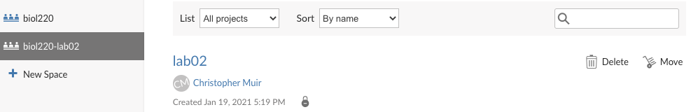

Each item listed under “All Projects” is a “Project” within the biol220-lab04 Workspace. Each week I will create a Project template that you will copy and work from (you cannot edit the original).

3. To create your own, click “START” to the left of “lab04”. Next week, it’ll be “lab05”, then “lab06”, etc.

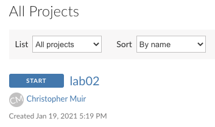

4. Once the Project is copied and deployed, rename the Project from “lab04” to include your name like this:

“lab04-muir-chris”

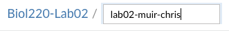

## Learning the Tools

### RStudio Primer on **dplyr** tools for working with data

In previous labs, we’ve used the **dplyr** package for functions like `filter()`, which filter your data by some condition. **dplyr** has many more useful tools for working with your data that you’ll use for today’s lesson on sampling distributions and for your group project.

We’re going to try something different. *RStudio* has already developed a really good Primer on **dplyr** that we have access to, so rather than write my own lab, I want you to go through their Primer. Hopefully it’s helpful, but let me know how you feel about it as I haven’t used it in class before.

Now you see a bunch of interactive Primers; select the one called “Work with Data”:

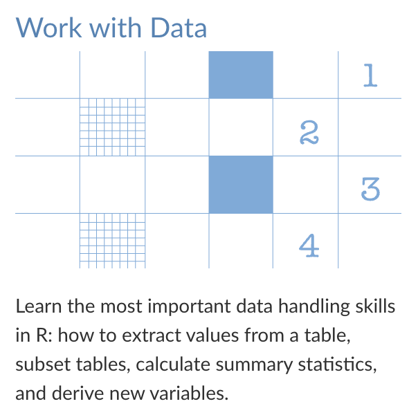

Now you’ll see three options: “Working with Tibbles”, “Isolating Data with dplyr”, and “Deriving Information with dplyr”:

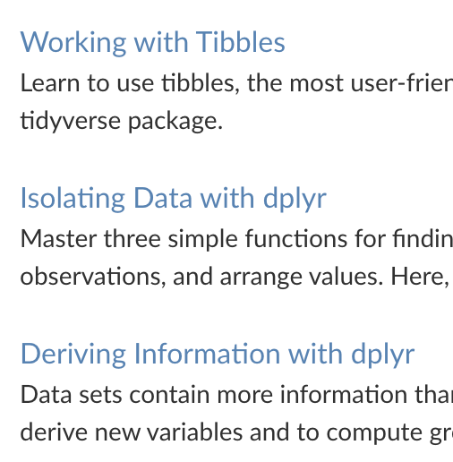

Work through them one-by-one in that order. There are several exercises and mini-quizzes throughout. I recommend you try these to test your understanding rather than just copy-and-pasting the solutions. However, I am not grading you on them and you do not need to include them in your lab report.

The first discusses **tibbles**, which are just user-friendly data frames. We’ve already encountered them because `read_csv()` automatically converts data to a **tibble**.

The second introduces key **dplyr** verbs for working with data like `filter()`, `select()`, and `arrange()`. It also introduces the pipe operator (`%>%`) which may be confusing at first, but I hope you will learn to appreciate it as your scripts grow more complex.

Finally, the last shows a new way to create new variables using `mutate()` and really useful functions to summarizing data by group.

Since you won’t be working in your script for this part, I recommend copying down important commands where you can refer to them (e.g. a Google Doc) or you can download this **dplyr** Cheat Sheet:

https://github.com/rstudio/cheatsheets/raw/master/data-transformation.pdf

### Simulating your own sampling distributions

Next, you’ll apply the **dplyr** tools to simulate your own sampling distribution of the mean. To do that, you’ll need to take many samples, calculate the sample mean $\bar{Y}$ for each, and plot the distribution.

#### Randomly sampling rows

You can take a random sample of rows in your data set using the **dplyr** function `slice_sample()`. For example, to sample 5 rows at random from the `iris` data set, you would do the following:

```r
# If you used the same seed as me, you should get the same answer
set.seed(20210203)
slice_sample(iris, n = 5)
```

```
##   Sepal.Length Sepal.Width Petal.Length Petal.Width    Species
## 1          5.2         3.5          1.5         0.2     setosa
## 2          5.8         2.7          3.9         1.2 versicolor
## 3          4.9         3.0          1.4         0.2     setosa
## 4          7.0         3.2          4.7         1.4 versicolor
## 5          6.0         2.9          4.5         1.5 versicolor
```

You could get the same result using the pipe operator like this:

```r
# If you used the same seed as me, you should get the same answer
set.seed(20210203)
iris %>%
  slice_sample(n = 5)
```

```
##   Sepal.Length Sepal.Width Petal.Length Petal.Width    Species
## 1          5.2         3.5          1.5         0.2     setosa
## 2          5.8         2.7          3.9         1.2 versicolor
## 3          4.9         3.0          1.4         0.2     setosa
## 4          7.0         3.2          4.7         1.4 versicolor
## 5          6.0         2.9          4.5         1.5 versicolor
```

Now try on your to increase the sample size 10.

#### Randomly sampling rows by group

You may have noticed that we sampled rows from multiple species. What if you want to sample 5 rows from each species? We can use the `group_by()` function to sampling within groups.

```r
# If you used the same seed as me, you should get the same answer
set.seed(20210203)
iris %>%
  group_by(Species) %>%
  slice_sample(n = 5)
```

```
## # A tibble: 15 x 5
## # Groups:   Species [3]
##    Sepal.Length Sepal.Width Petal.Length Petal.Width Species
##           <dbl>       <dbl>        <dbl>       <dbl> <fct>
##  1          5.2         3.5          1.5         0.2 setosa
##  2          4.5         2.3          1.3         0.3 setosa
##  3          5.7         3.8          1.7         0.3 setosa
##  4          4.9         3            1.4         0.2 setosa
##  5          5.8         4            1.2         0.2 setosa
##  6          6.6         3            4.4         1.4 versicolor
##  7          6.1         2.8          4.7         1.2 versicolor
##  8          5.8         2.6          4           1.2 versicolor
##  9          6.3         2.5          4.9         1.5 versicolor
## 10          5.4         3            4.5         1.5 versicolor
## 11          5.7         2.5          5           2   virginica
## 12          6.5         3            5.5         1.8 virginica
## 13          7.2         3            5.8         1.6 virginica
## 14          6.8         3            5.5         2.1 virginica
## 15          5.9         3            5.1         1.8 virginica
```

#### Repeated sampling

To simulate a sampling distribution, we need to repeatedly randomly sample the “population” (in this case, we’re pretending the `iris` data set is the entire population). The **infer** package has a convenient function `rep_slice_sample()` that will repeat `slice_sample()` many times. It creates a new column called `replicate` to index each replicate sample. To randomly sample 5 rows 4 times from *Iris setosa*, we do:

```r
# If you used the same seed as me, you should get the same answer
set.seed(20210203)
iris %>%
  filter(Species == "setosa") %>%
  rep_slice_sample(n = 5, reps = 4)
```

```
## # A tibble: 20 x 6
## # Groups:   replicate [4]
##    replicate Sepal.Length Sepal.Width Petal.Length Petal.Width Species
##        <int>        <dbl>       <dbl>        <dbl>       <dbl> <fct>
##  1         1          5.2         3.5          1.5         0.2 setosa
##  2         1          4.5         2.3          1.3         0.3 setosa
##  3         1          5.7         3.8          1.7         0.3 setosa
##  4         1          4.9         3            1.4         0.2 setosa
##  5         1          5.8         4            1.2         0.2 setosa
##  6         2          5           3            1.6         0.2 setosa
##  7         2          5.1         3.3          1.7         0.5 setosa
##  8         2          4.4         3.2          1.3         0.2 setosa
##  9         2          4.6         3.6          1           0.2 setosa
## 10         2          4.9         3.1          1.5         0.2 setosa
## 11         3          4.3         3            1.1         0.1 setosa
## 12         3          5.4         3.9          1.3         0.4 setosa
## 13         3          4.7         3.2          1.6         0.2 setosa
## 14         3          4.8         3            1.4         0.1 setosa
## 15         3          5           3.3          1.4         0.2 setosa
## 16         4          5           3.4          1.5         0.2 setosa
## 17         4          5.1         3.3          1.7         0.5 setosa
## 18         4          5.1         3.5          1.4         0.2 setosa
## 19         4          4.8         3            1.4         0.1 setosa
## 20         4          4.4         3.2          1.3         0.2 setosa
```

Hint: if that didn’t work, remember that you need load the **infer** package first.

Now, let’s take 1000 samples of 10 from each species. I’ll show you the code for *Iris setosa*, then fill in the `___` sections below to do it for it the other species. After, you’ll need to combine the results before summarizing and plotting.

```r
# If you used the same seed as me, you should get the same answer
set.seed(20210203)
setosa_sample_dist <- iris %>%
  filter(Species == "setosa") %>%
  rep_slice_sample(n = 10, reps = 1000)

versicolor_sample_dist <- iris %>%
  filter(Species == ___) %>%
  rep_slice_sample(n = 10, reps = 1000)

virginica_sample_dist <- iris %>%
  filter(Species == ___) %>%
  rep_slice_sample(n = 10, reps = 1000)
```

You can use the `bind_rows()` function to combine all three sets of sampling distributions into a single **tibble**.

```r
iris_sample_dists <- bind_rows(
  setosa_sample_dist,
  versicolor_sample_dist,
  virginica_sample_dist
)

iris_sample_dists
```

```
## # A tibble: 30,000 x 6
## # Groups:   replicate [1,000]
##    replicate Sepal.Length Sepal.Width Petal.Length Petal.Width Species
##        <int>        <dbl>       <dbl>        <dbl>       <dbl> <fct>
##  1         1          5.2         3.5          1.5         0.2 setosa
##  2         1          4.5         2.3          1.3         0.3 setosa
##  3         1          5.7         3.8          1.7         0.3 setosa
##  4         1          4.9         3            1.4         0.2 setosa
##  5         1          5.8         4            1.2         0.2 setosa
##  6         1          5           3            1.6         0.2 setosa
##  7         1          5.1         3.3          1.7         0.5 setosa
##  8         1          4.4         3.2          1.3         0.2 setosa
##  9         1          4.6         3.6          1           0.2 setosa
## 10         1          4.9         3.1          1.5         0.2 setosa
## # … with 29,990 more rows
```

Now we have a very large set of samples to examine.

### Sample mean $\bar{Y}$

To look at the distribution of the sample mean, we first need to calculate the sample mean for all 1000 replicates per species. Here is where we combine the power of `group_by()` and `summarize()`. This huge number of calculations can be done for `Sepal.Length` with the following code:

```r
sepal_length_sample_dists <- iris_sample_dists %>%
  group_by(Species, replicate) %>%
  summarize(Y_bar = mean(Sepal.Length))

sepal_length_sample_dists
```

```
## # A tibble: 3,000 x 3
## # Groups:   Species [3]
##    Species replicate Y_bar
##    <fct>       <int> <dbl>
##  1 setosa          1  5.01
##  2 setosa          2  4.91
##  3 setosa          3  5.14
##  4 setosa          4  5.19
##  5 setosa          5  4.87
##  6 setosa          6  4.87
##  7 setosa          7  5.26
##  8 setosa          8  5.04
##  9 setosa          9  4.89
## 10 setosa         10  4.82
## # … with 2,990 more rows
```

Modify the code above to calculate sample means for `Petal.Length`.

### Plot the sampling distribution $\bar{Y}$

We can apply the `ggplot()` tools we’ve already learned to plot a multiple histogram to compare the sampling distributions in each species.

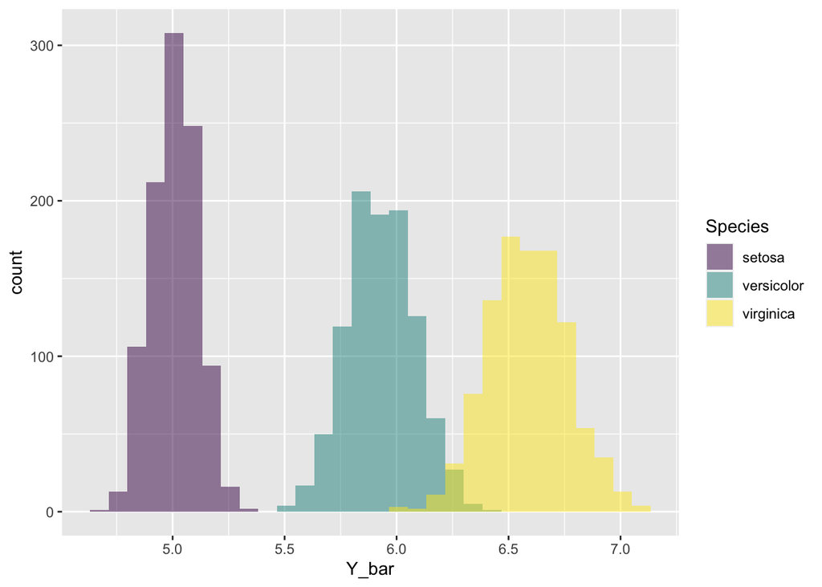

```r
ggplot(sepal_length_sample_dists, aes(Y_bar, fill = Species)) +
  geom_histogram(alpha = 0.5, position = "identity", bins = 30) +
  scale_fill_viridis_d()
```

See if you remember how to use `facet_grid()` to put each Specie in it’s own panel like this:

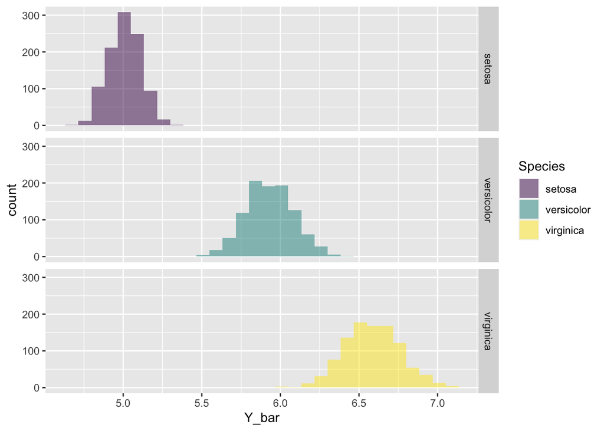

### Standard error of the mean

The standard error of the mean helps us quantify our uncertainty about our estimate of the population mean. But it’s also a *population* parameter given by the population standard deviation divided by the square-root of the sample size: $\sigma / \sqrt{n}$. Let’s again pretend that the `iris` data set is the “population”, the population standard deviation for `Sepal.Length` is:

| Species | $\sigma$ |
| --- | --- |
| setosa | 0.35 |
| versicolor | 0.51 |
| virginica | 0.62 |

Now calculate the population standard error of the mean for a sample size of 10. You should get:

| Species | $\sigma$ | $\sigma/\sqrt{n}$ |
| --- | --- | --- |
| setosa | 0.35 | 0.1106797 |
| versicolor | 0.51 | 0.1612762 |
| virginica | 0.62 | 0.1960612 |

Let’s compare the population standard error of the mean to what we obtain from our simulations. Remember that the standard error of the mean is simply the standard deviation of the sampling distribution. That means we can get the answer by using the `sd()` function on our simulated sampling distribution.

```r
sepal_length_sample_dists %>%
  group_by(Species) %>%
  summarize(SE_Ybar = sd(Y_bar))
```

```
## # A tibble: 3 x 2
##   Species    SE_Ybar
##   <fct>        <dbl>
## 1 setosa       0.101
## 2 versicolor   0.151
## 3 virginica    0.176
```

Notice that we had to first group by Species, then summarize by taking the standard deviation of all of our sample means.

Are the population standard errors of the mean close to what you calculated from the simulations? Are the standard errors what you expected given the multiple histogram figure above?

### Sample standard error of the mean

$$\mathrm{SE}_{\bar{Y}} = \frac{s}{\sqrt{n}}$$

There’s no function in *R* to calculate $\mathrm{SE}_{\bar{Y}}$, but you know the functions for sample standard deviation and square-root. Use *R* to calculate the sample standard error of the mean for the following numbers:

> 2.16 -0.79 -0.18 1.62 -0.98 -1.15 -0.15 1.34 1.96 1.74

You should get $\mathrm{SE}_{\bar{Y}}$ = 0.419.

### 95% confidence intervals

Confidence intervals are a way to show the plausible range of parameter values given the data. 95% confidence intervals will include the true population parameter 95% of the time. We’ll learn ways to calculate confidence intervals for different parameters throughout the class. Today, we’ll use the “2 SE” rule to approximate 95% confidence intervals for the sample mean $\bar{Y}$. The lower bound and upper bounds of the approximate 95% confidence interval using the 2 SE rule are:

$$\text{lower CI}: \bar{Y} - 2 \times \mathrm{SE}_{\bar{Y}}$$
$$\text{upper CI}: \bar{Y} + 2 \times \mathrm{SE}_{\bar{Y}}$$
Use the `mean()` functions and standard error of the mean to calculate the confidence interval for the data you used in the last section. You should get:

| $\bar{Y}$ | Lower CI | Upper CI |
| --- | --- | --- |
| 0.557 | -0.2813638 | 1.395364 |

## Optional Activities (do now or later)

Whitlock and Schluter have developed a couple interactive web apps demonstrating how the sampling distribution and confidence intervals work. I strongly encouraged to spend a few minutes exploring them. You could do it now, or while your working through this week’s lectures.

### Distribution of sample means

Go to the web and open the page at http://www.zoology.ubc.ca/~whitlock/kingfisher/SamplingNormal.htm. This page contains some interactive visualizations that let you play around with sampling to see the distribution of sampling means. Click the button that says “Tutorial” near the bottom of the page and follow along with the instructions.

### Confidence intervals

Go back to the web, and open the page at http://www.zoology.ubc.ca/~whitlock/kingfisher/CIMean.htm. This applet draws confidence intervals for the mean of a known population. Click “Tutorial” again, and follow along.

## Questions

### 1. Sampling distribution of $\bar{Y}$

#### a. Import data

As we did in class, we’ll use the leaf size data from Wright *et al.* 2017[^1]. We’ll pretend that this is population of all leaf sizes in the world and look at the properties of random samples from the population.

Use the `read_csv()` and **dplyr** verbs to

- import the data as a **tibble**
- select `latitude` and `leafsize_cm2` columns only
- filter out all missing values from `leafsize_cm2`
- filter the data to only tropical latitudes between -23.43655° and 23.43655°
- assign the **tibble** with the name `leafsize`

If you’ve done everything correctly, you should get the same values for the population mean seen below:

```r
mean(leafsize$leafsize_cm2)
```

```
## [1] 65.97642
```

#### b. Sampling distributions for $n = 64$, $n = 256$, and $n = 1024$

Create 1000 replicates each of sample sizes of 64, 256, and 1024 from the `leafize` tibble you generated in a. I’ll show you the code for $n = 64$, then you should copy and modify it to make similar objects called `sample_dist256` and `sample_dist1024`. Then use `bind_rows()` to combine them into an object called `sample_dists`.

```r
sample_dist64 <- leafsize %>%
  rep_slice_sample(n = 64, reps = 1e3) %>%
  mutate(sample_size = 64)

sample_dist256 <- ___

sample_dist1024 <- ___

sample_dists <- ___
```

#### c. Use the `group_by()` and `summarize()` functions to calculate the sample mean for each level of sample size (64, 256, or 1024) and replicate. Make sure you assign the output a name so you can use it to make a plot in the next part.

#### d. Make a multiple histogram with separate panels for each sample size. It should look something like this, but will not be exactly the same because the simulations are random.

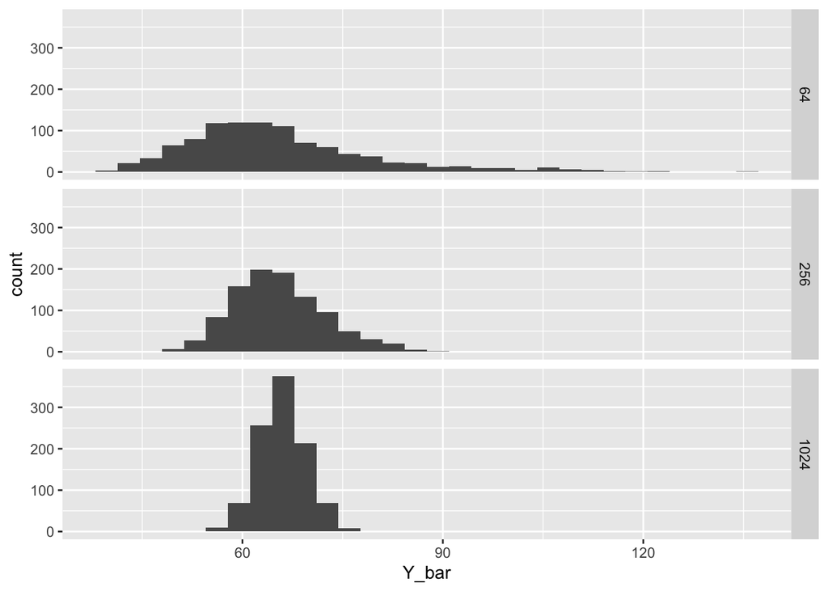

#### e. How does the location, width, and skew of the sampling distribution for $\bar{Y}$ change as $n$ increases?

[^1]: The original paper can be found [here](https://doi.org/10.1126/science.aal4760)